# Homework 7

Araks Karapetyan

10.12.2018

(3 points) Read the file Mystery shopping. The description of the file is provided in the separate file. Run some summary statistics and make visualizations to identify variables which can be used for cluster analysis in order to categorize the employees of the company. Make sure to the variables selected by you are numeric.

```r
myst_shop <- read.csv("Mystery shopping.csv")
summary(myst_shop)
```

```
##      ï..ID        Experience         Age             Wage
##  Min.   : 1.0   Min.   :1.000   Min.   :22.00   Min.   :4720
##  1st Qu.: 9.5   1st Qu.:2.000   1st Qu.:26.00   1st Qu.:4808
##  Median :18.0   Median :3.000   Median :29.00   Median :5023
##  Mean   :18.0   Mean   :3.343   Mean   :30.51   Mean   :5115
##  3rd Qu.:26.5   3rd Qu.:4.500   3rd Qu.:35.00   3rd Qu.:5284
##  Max.   :35.0   Max.   :7.000   Max.   :43.00   Max.   :6236
##  Family_status     Education     professionalism  benevolence
##  Min.   :1.000   Min.   :1.000   Min.   :27.70   Min.   :35.50
##  1st Qu.:1.000   1st Qu.:1.000   1st Qu.:37.95   1st Qu.:46.30
##  Median :1.000   Median :2.000   Median :46.50   Median :52.40
##  Mean   :1.457   Mean   :1.943   Mean   :47.73   Mean   :55.25
##  3rd Qu.:2.000   3rd Qu.:2.000   3rd Qu.:57.60   3rd Qu.:65.40
##  Max.   :2.000   Max.   :3.000   Max.   :66.20   Max.   :76.60
##  communicability   appearance   prof_after_training
##  Min.   :20.50   Min.   :66.7   Min.   :39.70
##  1st Qu.:32.30   1st Qu.:78.0   1st Qu.:48.85
##  Median :39.20   Median :87.0   Median :53.70
##  Mean   :38.18   Mean   :84.6   Mean   :55.98
##  3rd Qu.:42.40   3rd Qu.:90.4   3rd Qu.:61.50
##  Max.   :57.30   Max.   :98.1   Max.   :75.60
```

```r
str(myst_shop)
```

```
## 'data.frame':    35 obs. of  11 variables:
##  $ ï..ID              : int  13 19 2 1 33 27 3 17 21 18 ...
##  $ Experience         : int  6 1 1 1 6 3 1 1 1 1 ...
##  $ Age                : int  35 23 22 24 36 25 33 25 34 26 ...
##  $ Wage               : num  4720 4731 4741 4775 4782 ...
##  $ Family_status      : int  1 2 2 2 1 1 2 2 2 1 ...
##  $ Education          : int  1 1 1 2 1 2 3 2 3 1 ...
##  $ professionalism    : num  51.4 48.9 48 38.9 51.8 59.3 33.9 40.9 34.3 43.9 ...
##  $ benevolence        : num  45 57.1 55.1 49.1 46.6 66.8 35.5 52.2 39.2 75.2 ...
##  $ communicability    : num  35.7 40.1 40 41.7 36.4 35.7 42.1 45.6 42.3 35 ...
##  $ appearance         : num  66.7 95 91.7 87.5 69.6 89.2 83.3 88.9 87 82.2 ...
##  $ prof_after_training: num  59 58.9 57 49 59 60.2 43 50.4 43.8 52.4 ...
```

```r
rownames(myst_shop) <- myst_shop$ï..ID
myst_shop1 <- myst_shop[1:10, c("professionalism", "benevolence", "communicability", "appearance")]
dist <- dist(myst_shop1, method="euclidian")
dist
```

```
##           13        19         2         1        33        27         3
## 19 31.191505
## 2  27.514723  3.963584
## 1  25.331798 14.926821 11.804237
## 33  3.408812 27.883866 24.249948 22.828929
## 27 32.309441 15.976545 17.009409 27.718947 29.136575
## 3  26.702434 28.852210 25.650341 15.091720 25.764316 41.238574
## 17 27.439752 12.468761  9.900505  5.547973 24.643458 25.491567 19.274335
## 21 27.958898 24.544042 21.630534 10.944405 26.430664 37.883506  5.251666
## 18 34.771109 23.290771 23.153186 27.913975 32.265926 18.900000 41.565731
##           17        21
## 19
## 2
## 1
## 33
## 27
## 3
## 17
## 21 15.068510
## 18 26.367594 38.268656
```

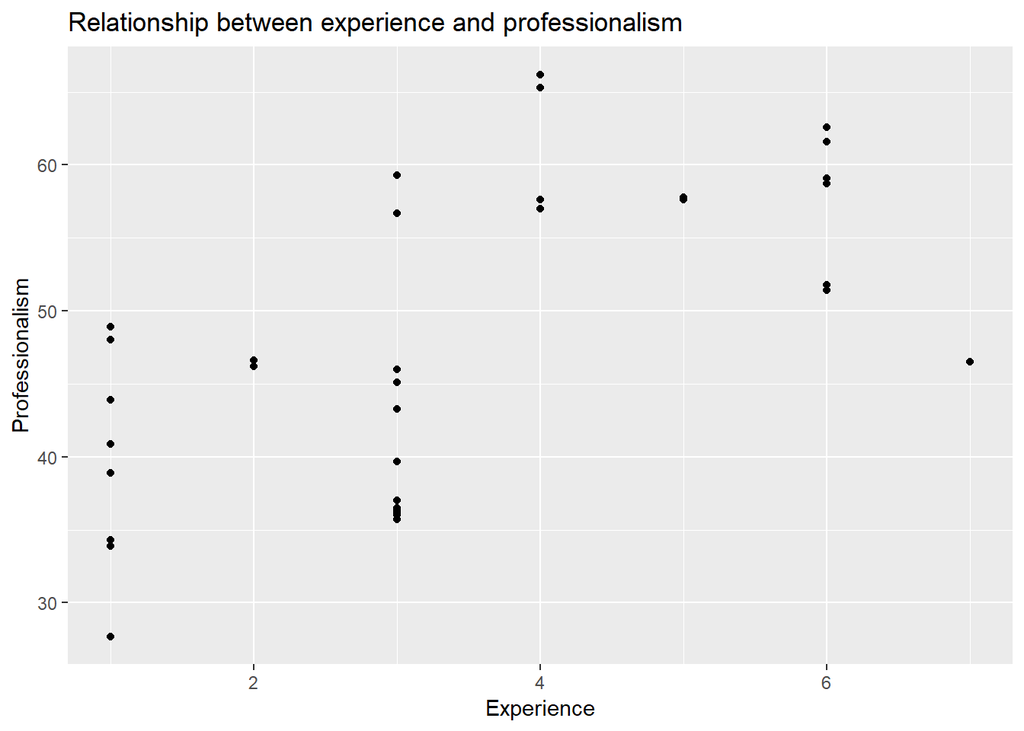

```r
library(ggplot2)
ggplot(myst_shop, aes(x = Experience, y = professionalism)) + geom_point() + labs(x = "Experience", y = "Professionalism", title = "Relationship between experience and professionalism")
```

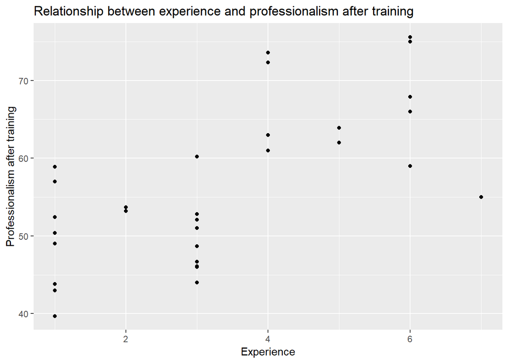

```r
ggplot(myst_shop, aes(x = Experience, y = prof_after_training)) + geom_point()+ labs(x = "Experience", y = "Professionalism after training", title = "Relationship between experience and professionalism after training")
```

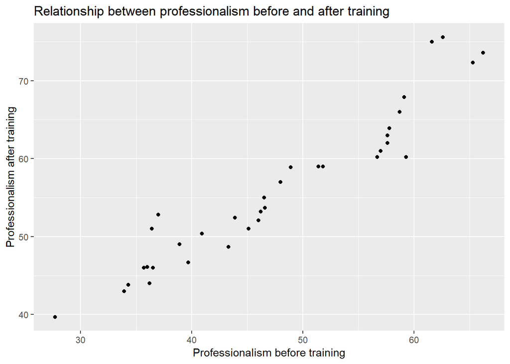

```r
ggplot(myst_shop, aes(x = professionalism, y = prof_after_training)) + geom_point() + labs(x = "Professionalism before training", y = "Professionalism after training", title = "Relationship between professionalism before and after training")
```

(7 points) Check if the measurement scale for each selected variable is similar or do we need normalization? If we need, scale the variables before clustering task. Run hierarchical cluster analysis on the variables identified in the previous question. Plot a dendrogram and comment on how many clusters it is effective to choose after choosing the number of clusters to be chosen, save the cluster membership variable.

```r
myst_shop2 <- as.data.frame(scale(myst_shop1, center = T, scale = T))
dist <- dist(myst_shop2, method = "euclidian")
cl <- hclust(dist, method = "complete")
cl$merge
```

```
##       [,1] [,2]
##  [1,]   -1   -5
##  [2,]   -2   -3
##  [3,]   -7   -9
##  [4,]   -4   -8
##  [5,]    2    4
##  [6,]   -6  -10
##  [7,]    3    5
##  [8,]    1    6
##  [9,]    7    8
```

```r
cl$height
```

```
## [1] 0.3963909 0.4106125 0.5105476 1.1525091 1.9740663 2.1460934 2.9060094
## [8] 3.1855009 4.4533632
```

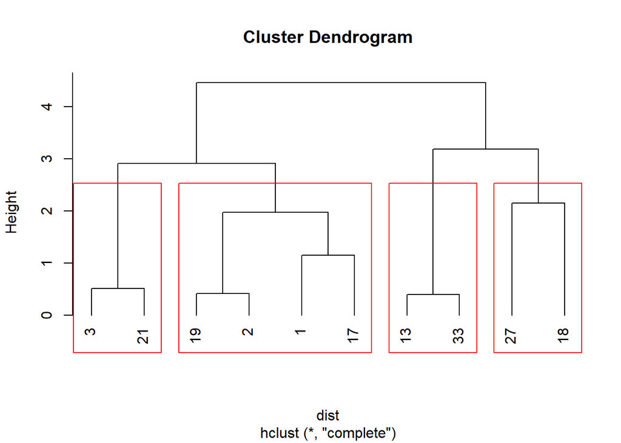

```r
plot(cl, hang = -1)
rect.hclust(cl, k = 4)
```

```r
#To escape underfitting, it is effective to take 4 clusters.

myst_shop1$cluster <- cutree(cl, k = 4)
```

(7 points) Use the kmeans algorithm to build the clusters to categorize employees based on the variables of your choice. Run the analysis using several number of clusters (k) Comment on which model is better? Save the cluster memberships of the best model

```r
set.seed(1)
km1 <- kmeans(myst_shop, 2)
km1
```

```
## K-means clustering with 2 clusters of sizes 22, 13
##
## Cluster means:
##      ï..ID Experience      Age     Wage Family_status Education
## 1 17.36364   2.818182 30.45455 4909.657      1.454545  1.863636
## 2 19.07692   4.230769 30.61538 5462.999      1.461538  2.076923
##   professionalism benevolence communicability appearance
## 1        43.66818    54.71818        35.59091   83.24091
## 2        54.59231    56.16154        42.56154   86.89231
##   prof_after_training
## 1            52.93182
## 2            61.13077
##
## Clustering vector:
## 13 19  2  1 33 27  3 17 21 18 20  5  9 35 15  6 28 23  8 26 29 24 10 31 30
##  1  1  1  1  1  1  1  1  1  1  1  1  1  1  1  1  1  1  1  1  1  1  2  2  2
##  7 11 25  4 22 12 32 34 14 16
##  2  2  2  2  2  2  2  2  2  2
##
## Within cluster sum of squares by cluster:
## [1] 424413.3 996152.0
##  (between_SS / total_SS =  63.8 %)
##
## Available components:
##
## [1] "cluster"      "centers"      "totss"        "withinss"
## [5] "tot.withinss" "betweenss"    "size"         "iter"
## [9] "ifault"
```

```r
km1$betweenss/km1$totss
```

```
## [1] 0.6380396
```